# Katarzyna_Wesolowska_CaseStudy

Katarzyna Wesołowska

2025-12-14

# 1. Business Understanding

**Cel projektu:** przewidywanie liczby ofiar śmiertelnych (`FATALS`) na podstawie cech opisujących wypadek drogowy.

**Typ problemu:** regresja.

**Modele:** - Model 1 (wylosowany): **sieć neuronowa MLP** - Model 2 (dobrany): **Random Forest**

**Uzasadnienie wyboru modeli:** Model MLP został wylosowany i jest zgodny z typem problemu (regresja – przewidujemy liczbową zmienną `FATALS`). Dodatkowo sprawdzam Random Forest, bo zwykle dobrze radzi sobie na danych tablicowych, jest mniej wrażliwy na nietypowe rozkłady i daje interpretowalność przez ważność zmiennych. Dane są mocno niezbalansowane (dominuje `FATALS=1`), dlatego porównanie MLP vs RF ma sens, bo oba modele mogą inaczej reagować na rzadkie wartości 2–6.

# 2. Data Understanding

## 2.1 Biblioteki

```r
#install.packages(c("caret","nnet","corrplot","GGally","randomForest", "randomForest"))

library(tidyverse)
library(caret)
library(nnet)
library(ggplot2)
library(corrplot)
library(GGally)
library(randomForest)
```

## 2.2 Wczytanie danych

Plik zawiera opis + dane. Wczytujemy dopiero od linii z nagłówkiem `"VE_TOTAL"...`.

```r
path <- "C:/Users/wesol/OneDrive/Pulpit/Studia/Semestr VII/Data Mining/california_accidents.txt"
lines <- readLines(path)
start <- which(grepl('^"VE_TOTAL"', lines))

df_raw <- read.table(
  text = lines[start:length(lines)],
  sep = "\t",
  header = TRUE,
  stringsAsFactors = FALSE
)

head(df_raw)
```

|  | VE_TOTAL.PERSONS.PEDS.NO_LANES.SP_LIMIT.FATALS.DRUNK_DR |
| --- | --- |
| 2 | 1,2,1,3,0,1,0 |
| 3 | 1,1,0,2,0,1,1 |
| 4 | 3,3,0,2,0,1,0 |
| 5 | 2,2,0,2,0,1,0 |
| 6 | 1,6,0,2,0,3,0 |
| 7 | 2,8,0,2,15,1,0 |

```r
str(df_raw)
```

```
## 'data.frame':    1741 obs. of  1 variable:
##  $ VE_TOTAL.PERSONS.PEDS.NO_LANES.SP_LIMIT.FATALS.DRUNK_DR: chr  "1,2,1,3,0,1,0" "1,1,0,2,0,1,1" "3,3,0,2,0,1,0" "2,2,0,2,0,1,0" ...
```

```r
names(df_raw)
```

```
## [1] "VE_TOTAL.PERSONS.PEDS.NO_LANES.SP_LIMIT.FATALS.DRUNK_DR"
```

## 2.3 Rozbicie kolumny na zmienne

W danych wszystko było w jednej kolumnie tekstowej, więc rozdzielamy po przecinku.

```r
# VE_TOTAL - # of vehicles involved in the crash
#   PERSONS - # of people involved in the crash
#   PEDS - # of pedestrians involved in the crash
#   NO_LANES - # of lanes of the road the crash occurred on
#   SP_LIMIT – The speed limit at the location of the crash
# FATALS - # of people who died as a result of the crash
#   DRUNK_DR - # of alcohol influenced drivers involved in the crash

df <- df_raw %>%
  separate(
    col = 1,
    into = c(
      "VE_TOTAL",
      "PERSONS",
      "PEDS",
      "NO_LANES",
      "SP_LIMIT",
      "FATALS",
      "DRUNK_DR"
    ),
    sep = ",",
    convert = TRUE
  )

head(df)
```

|  | VE_TOTAL | PERSONS | PEDS | NO_LANES | SP_LIMIT | FATALS | DRUNK_DR |
| --- | --- | --- | --- | --- | --- | --- | --- |
| 2 | 1 | 2 | 1 | 3 | 0 | 1 | 0 |
| 3 | 1 | 1 | 0 | 2 | 0 | 1 | 1 |
| 4 | 3 | 3 | 0 | 2 | 0 | 1 | 0 |
| 5 | 2 | 2 | 0 | 2 | 0 | 1 | 0 |
| 6 | 1 | 6 | 0 | 2 | 0 | 3 | 0 |
| 7 | 2 | 8 | 0 | 2 | 15 | 1 | 0 |

# 3. Data Preparation

Na tym etapie **nie usuwamy duplikatów**, bo duplikaty mogą oznaczać wiele wypadków o tych samych parametrach.

## 3.1 Kontrola typów, braków, duplikatów

```r
str(df)
```

```
## 'data.frame':    1741 obs. of  7 variables:
##  $ VE_TOTAL: int  1 1 3 2 1 2 1 1 1 1 ...
##  $ PERSONS : int  2 1 3 2 6 8 2 2 1 2 ...
##  $ PEDS    : int  1 0 0 0 0 0 1 1 0 0 ...
##  $ NO_LANES: int  3 2 2 2 2 2 2 2 2 2 ...
##  $ SP_LIMIT: int  0 0 0 0 0 15 15 15 20 20 ...
##  $ FATALS  : int  1 1 1 1 3 1 1 1 1 1 ...
##  $ DRUNK_DR: int  0 1 0 0 0 0 1 2 1 0 ...
```

```r
colSums(is.na(df))
```

```
## VE_TOTAL  PERSONS     PEDS NO_LANES SP_LIMIT   FATALS DRUNK_DR
##        0        0        0        0        0        0        0
```

```r
sum(duplicated(df))
```

```
## [1] 947
```

```r
summary(df)
```

```
##     VE_TOTAL         PERSONS            PEDS           NO_LANES
##  Min.   : 1.000   Min.   : 1.000   Min.   :0.0000   Min.   :1.000
##  1st Qu.: 1.000   1st Qu.: 2.000   1st Qu.:0.0000   1st Qu.:2.000
##  Median : 1.000   Median : 2.000   Median :0.0000   Median :2.000
##  Mean   : 1.589   Mean   : 2.779   Mean   :0.2252   Mean   :2.846
##  3rd Qu.: 2.000   3rd Qu.: 3.000   3rd Qu.:0.0000   3rd Qu.:4.000
##  Max.   :10.000   Max.   :25.000   Max.   :5.0000   Max.   :9.000
##     SP_LIMIT         FATALS         DRUNK_DR
##  Min.   : 0.00   Min.   :1.000   Min.   :0.0000
##  1st Qu.:40.00   1st Qu.:1.000   1st Qu.:0.0000
##  Median :55.00   Median :1.000   Median :0.0000
##  Mean   :49.44   Mean   :1.111   Mean   :0.4607
##  3rd Qu.:65.00   3rd Qu.:1.000   3rd Qu.:1.0000
##  Max.   :70.00   Max.   :6.000   Max.   :6.0000
```

```r
table(df$FATALS)
```

```
##
##    1    2    3    4    5    6
## 1586  125   24    4    1    1
```

**Interpretacja:** - Brak braków danych (`NA` = 0 dla każdej kolumny). - Duplikaty: **947** (zostawiamy). - `FATALS` jest mocno niezbalansowane: najczęściej **1**, rzadko wartości 3–6.

# 4. Exploratory Data Analysis (EDA)

## 4.1 Rozkład zmiennej docelowej

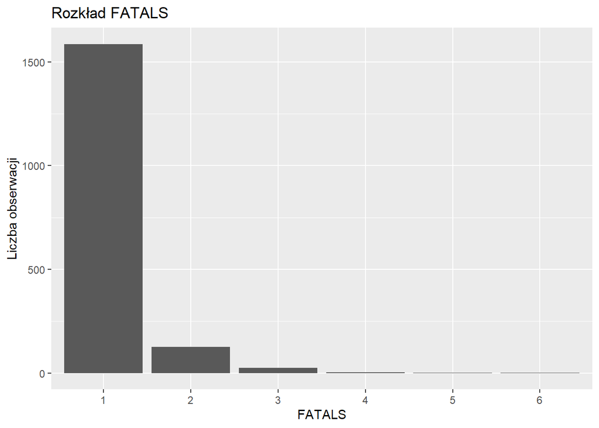

```r
ggplot(df, aes(x = factor(FATALS))) +
  geom_bar() +
  labs(x = "FATALS", y = "Liczba obserwacji", title = "Rozkład FATALS")
```

**Komentarz:** Widać bardzo silną nierównowagę: zdecydowana większość obserwacji ma FATALS = 1, a wartości 2–6 są rzadkie. To od razu sugeruje, że modele będą miały tendencję do „ciągnięcia” predykcji w okolice 1.

## 4.2 Zależności cech z `FATALS`

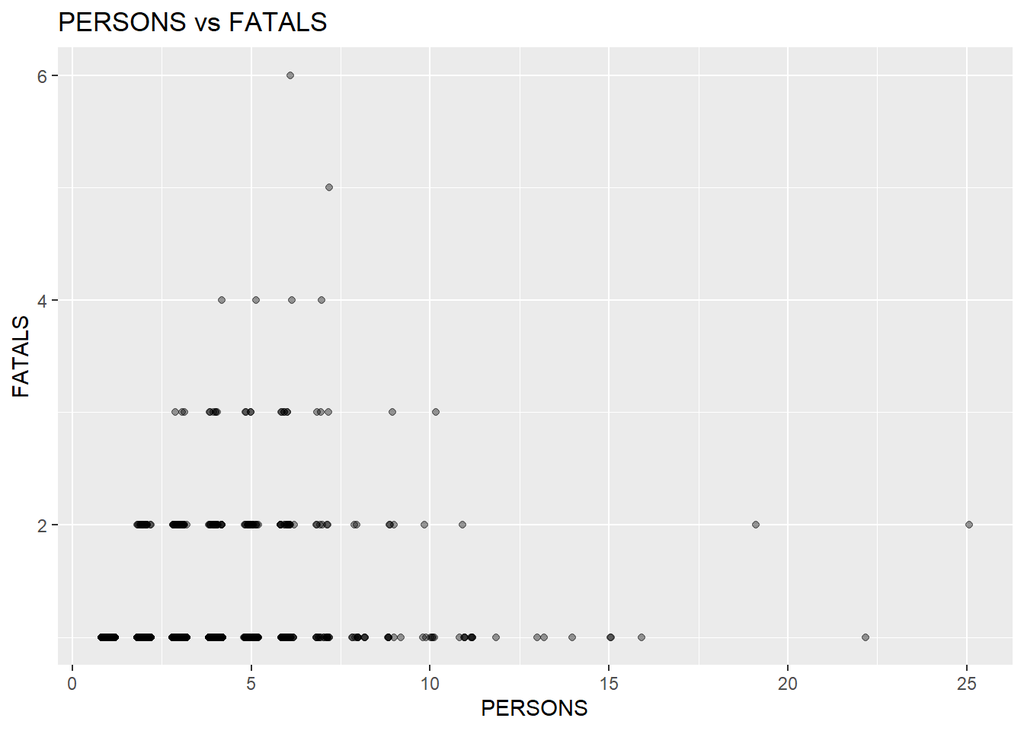

```r
ggplot(df, aes(x = PERSONS, y = FATALS)) +
  geom_jitter(width = 0.2,
              height = 0,
              alpha = 0.4) +
  labs(title = "PERSONS vs FATALS")
```

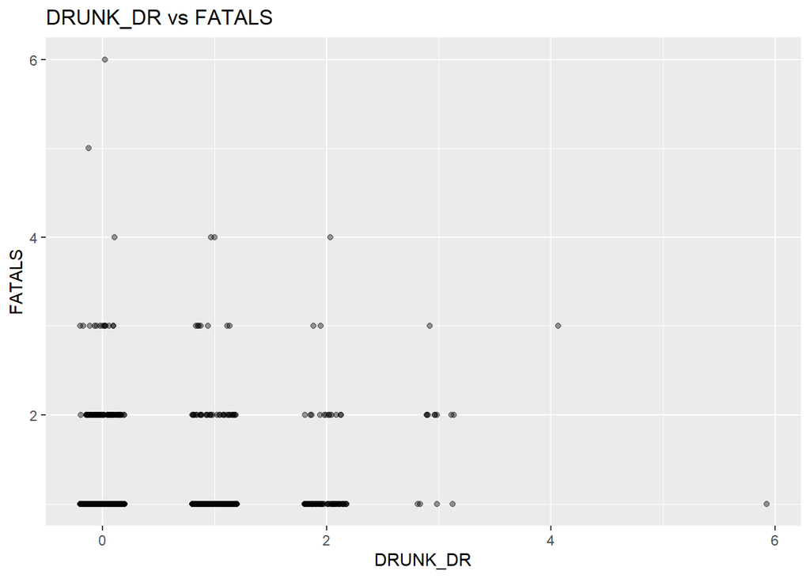

```r
ggplot(df, aes(x = DRUNK_DR, y = FATALS)) +
  geom_jitter(width = 0.2,
              height = 0,
              alpha = 0.4) +
  labs(title = "DRUNK_DR vs FATALS")
```

**Komentarz:** PERSONS vs FATALS Punkty pokazują, że wraz ze wzrostem liczby osób w wypadku może rosnąć liczba ofiar, ale zależność nie jest idealna (duży rozrzut). W praktyce: PERSONS jest sensowną cechą, ale nie wystarczy sama.

DRUNK_DR vs FATALS Widać, że dla większej liczby nietrzeźwych kierowców pojawiają się częściej przypadki z wyższym FATALS, ale nadal dominuje FATALS=1. Czyli DRUNK_DR pomaga, ale efekt ginie przez niezbalansowanie danych.

## 4.3 Korelacje między zmiennymi

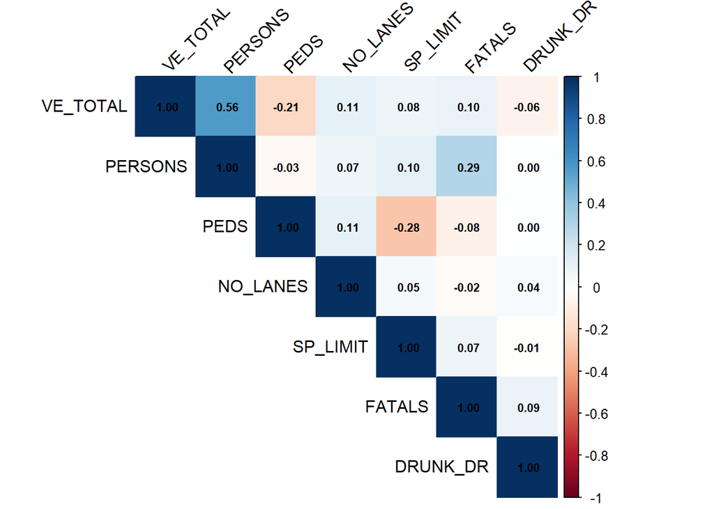

```r
M <- cor(df, use = "complete.obs")
corrplot(
  M,
  method = "color",
  type = "upper",
  addCoef.col = "black",
  tl.col = "black",
  tl.srt = 45,
  number.cex = 0.7
)
```

## 4.4 Dodatkowe zależności (boxploty + tabele)

```r
# Problem: regresja
# Zmienna objaśniana (y): FATALS
# Cel: przewidywanie liczby ofiar śmiertelnych

summary(df$FATALS)
```

```
##    Min. 1st Qu.  Median    Mean 3rd Qu.    Max.
##   1.000   1.000   1.000   1.111   1.000   6.000
```

```r
table(df$FATALS) #dane niezbalansowane
```

```
##
##    1    2    3    4    5    6
## 1586  125   24    4    1    1
```

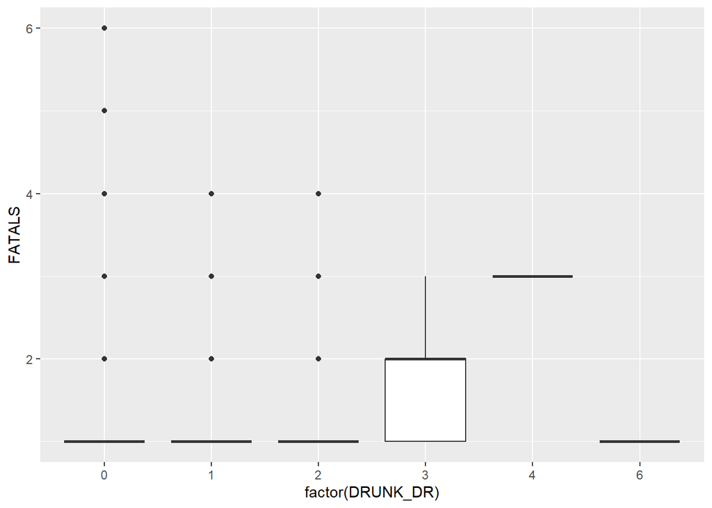

```r
ggplot(df, aes(x = factor(DRUNK_DR), y = FATALS)) + geom_boxplot()
```

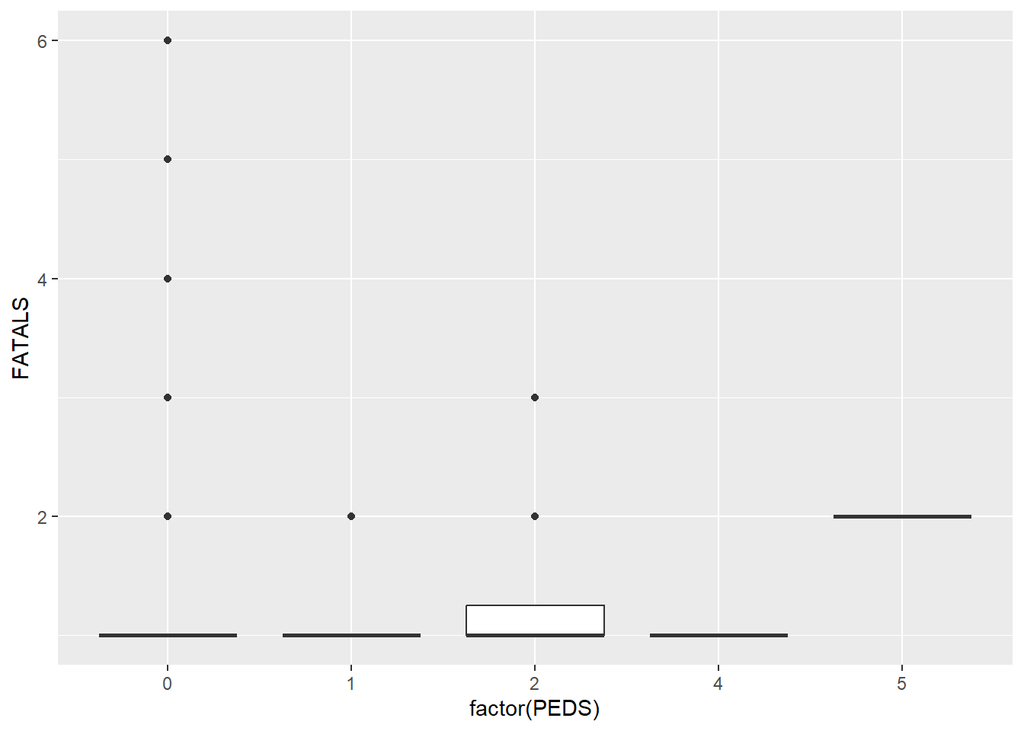

```r
ggplot(df, aes(x = factor(PEDS), y = FATALS)) + geom_boxplot()
```

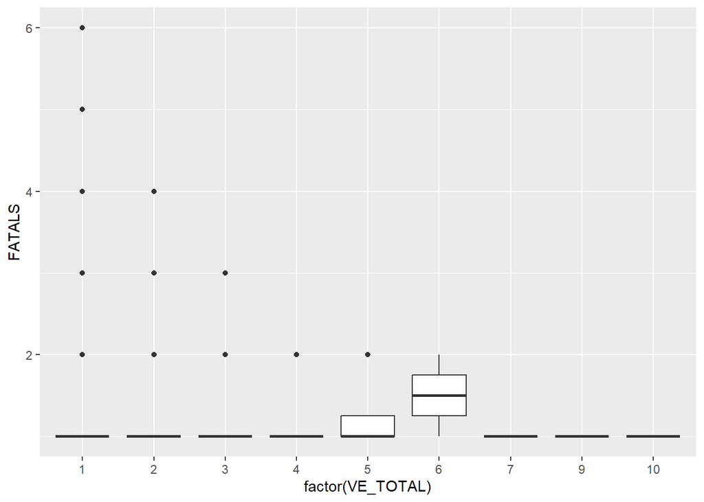

```r
ggplot(df, aes(x = factor(VE_TOTAL), y = FATALS)) + geom_boxplot()
```

```r
prop.table(table(df$FATALS, df$DRUNK_DR), margin = 2)
```

```
##
##                0            1            2            3            4
##   1 0.9169027384 0.9277108434 0.8255813953 0.3076923077 0.0000000000
##   2 0.0679886686 0.0567986231 0.1395348837 0.6153846154 0.0000000000
##   3 0.0122757318 0.0120481928 0.0232558140 0.0769230769 1.0000000000
##   4 0.0009442871 0.0034423408 0.0116279070 0.0000000000 0.0000000000
##   5 0.0009442871 0.0000000000 0.0000000000 0.0000000000 0.0000000000
##   6 0.0009442871 0.0000000000 0.0000000000 0.0000000000 0.0000000000
##
##                6
##   1 1.0000000000
##   2 0.0000000000
##   3 0.0000000000
##   4 0.0000000000
##   5 0.0000000000
##   6 0.0000000000
```

```r
prop.table(table(df$FATALS, df$PEDS), margin = 2)
```

```
##
##                0            1            2            4            5
##   1 0.8924418605 0.9970845481 0.7500000000 1.0000000000 0.0000000000
##   2 0.0864825581 0.0029154519 0.2000000000 0.0000000000 1.0000000000
##   3 0.0167151163 0.0000000000 0.0500000000 0.0000000000 0.0000000000
##   4 0.0029069767 0.0000000000 0.0000000000 0.0000000000 0.0000000000
##   5 0.0007267442 0.0000000000 0.0000000000 0.0000000000 0.0000000000
##   6 0.0007267442 0.0000000000 0.0000000000 0.0000000000 0.0000000000
```

```r
df %>%
  group_by(PEDS, DRUNK_DR) %>%
  summarise(n = n(),
            mean_FATALS = mean(FATALS),
            .groups = "drop") %>%
  arrange(desc(n))
```

| PEDS | DRUNK_DR | n | mean_FATALS |
| --- | --- | --- | --- |
| 0 | 0 | 838 | 1.124105 |
| 0 | 1 | 463 | 1.110151 |
| 1 | 0 | 207 | 1.000000 |
| 1 | 1 | 111 | 1.009009 |
| 0 | 2 | 60 | 1.316667 |
| 1 | 2 | 25 | 1.000000 |
| 0 | 3 | 13 | 1.769231 |
| 2 | 0 | 13 | 1.384615 |
| 2 | 1 | 6 | 1.166667 |
| 0 | 4 | 1 | 3.000000 |

[output cut: 4 more lines]

**Komentarz:**  
Boxplot: DRUNK_DR (kategorie) vs FATALS Dla wyższych DRUNK_DR rozkład FATALS może mieć wyższe „ogonki” (pojedyncze większe wartości). Nadal mediany zwykle siedzą przy 1, bo danych z >1 jest mało.

Boxplot: VE_TOTAL (kategorie) vs FATALS Więcej pojazdów może podnosić ryzyko, ale znów: dominacja FATALS=1 sprawia, że różnice między grupami nie są spektakularne.

# 5. Modeling

## 5.1 Podział na zbiory: predykcyjny (4), treningowy i walidacyjny

```r
set.seed(123)

n <- nrow(df)

idx_pred <- sample(1:n, 4)
pred <- df[idx_pred, ]

rest <- df[-idx_pred, ]

idx_train <- sample(1:nrow(rest), size = round(0.8 * nrow(rest)))
train <- rest[idx_train, ]
valid <- rest[-idx_train, ]

nrow(train)
```

```
## [1] 1390
```

```r
nrow(valid)
```

```
## [1] 347
```

```r
nrow(pred)
```

```
## [1] 4
```

**Interpretacja:** - Train: **1390** - Valid: **347** - Predykcja: **4**

## 5.2 Preprocessing pod MLP: skalowanie zmiennych

Sieci neuronowe bardzo źle znoszą różne skale cech, więc skalujemy wejścia na podstawie `train`.

```r
y_train <- train$FATALS
y_valid <- valid$FATALS
y_pred  <- pred$FATALS

X_train_raw <- train %>% select(-FATALS)
X_valid_raw <- valid %>% select(-FATALS)
X_pred_raw  <- pred  %>% select(-FATALS)


pp <- preProcess(X_train_raw, method = c("center", "scale"))
X_train <- predict(pp, X_train_raw)
X_valid <- predict(pp, X_valid_raw)
X_pred  <- predict(pp, X_pred_raw)
```

## 5.3 Model 1: MLP (nnet) — kilka wariantów + wybór najlepszego

```r
fit_eval_mlp <- function(seed,
                         size,
                         decay,
                         maxit,
                         Xtr,
                         ytr,
                         Xva,
                         yva,
                         Xpr,
                         ypr,
                         name) {
  set.seed(seed)
  m <- nnet(
    x = as.matrix(Xtr),
    y = ytr,
    size = size,
    decay = decay,
    maxit = maxit,
    linout = TRUE,
    trace = FALSE
  )


  pred_va <- predict(m, as.matrix(Xva))
  rmse <- sqrt(mean((yva - pred_va)^2))
  mae  <- mean(abs(yva - pred_va))


  pred_pr <- as.numeric(predict(m, as.matrix(Xpr)))
  pred_pr_round <- pmax(0, round(pred_pr))   # bo FATALS to liczby całkowite >= 0

  list(
    model = m,
    metrics = data.frame(
      Variant = name,
      RMSE_valid = rmse,
      MAE_valid = mae
    ),
    pred_table = data.frame(
      FATALS_true = ypr,
      pred_raw = pred_pr,
      pred_round = pred_pr_round
    )
  )
}
```

### Wariant 1: Base

```r
mlp1 <- fit_eval_mlp(
  seed = 123,
  size = 5,
  decay = 0.001,
  maxit = 500,
  Xtr = X_train,
  ytr = y_train,
  Xva = X_valid,
  yva = y_valid,
  Xpr = X_pred,
  ypr = y_pred,
  name = "MLP_base (size=5, decay=0.001)"
)
```

### Wariant 2: Większa sieć

```r
mlp2 <- fit_eval_mlp(
  seed = 999,
  size = 10,
  decay = 0.0001,
  maxit = 800,
  Xtr = X_train,
  ytr = y_train,
  Xva = X_valid,
  yva = y_valid,
  Xpr = X_pred,
  ypr = y_pred,
  name = "MLP_big (size=10, decay=0.0001)"
)
```

```r
feat_small <- c("PERSONS",
                "PEDS",
                "DRUNK_DR",
                "SP_LIMIT",
                "NO_LANES",
                "VE_TOTAL")

X_train_s <- X_train_raw %>% select(all_of(feat_small))
X_valid_s <- X_valid_raw %>% select(all_of(feat_small))
X_pred_s  <- X_pred_raw  %>% select(all_of(feat_small))

pp_s <- preProcess(X_train_s, method = c("center", "scale"))
X_train_s <- predict(pp_s, X_train_s)
X_valid_s <- predict(pp_s, X_valid_s)
X_pred_s  <- predict(pp_s, X_pred_s)

mlp3 <- fit_eval_mlp(
  seed = 123,
  size = 3,
  decay = 0.01,
  maxit = 500,
  Xtr = X_train_s,
  ytr = y_train,
  Xva = X_valid_s,
  yva = y_valid,
  Xpr = X_pred_s,
  ypr = y_pred,
  name = "MLP_small_feat (6 cech, size=3, decay=0.01)"
)
```

### Porównanie wariantów MLP

```r
results_mlp <- bind_rows(mlp1$metrics, mlp2$metrics, mlp3$metrics)
results_mlp
```

| Variant | RMSE_valid | MAE_valid |
| --- | --- | --- |
| MLP_base (size=5, decay=0.001) | 0.4820539 | 0.1893815 |
| MLP_big (size=10, decay=0.0001) | 0.5098030 | 0.2184491 |
| MLP_small_feat (6 cech, size=3, decay=0.01) | 0.4551954 | 0.1893670 |

**Interpretacja:** - `MLP_small_feat` ma najlepszy **RMSE_valid ≈ 0.455** (niżej = lepiej). - `MLP_big` wypadł najsłabiej (RMSE ok. 0.510), czyli większa sieć nie zawsze pomaga.

### Wybór najlepszego wariantu MLP + analiza błędów na walidacji

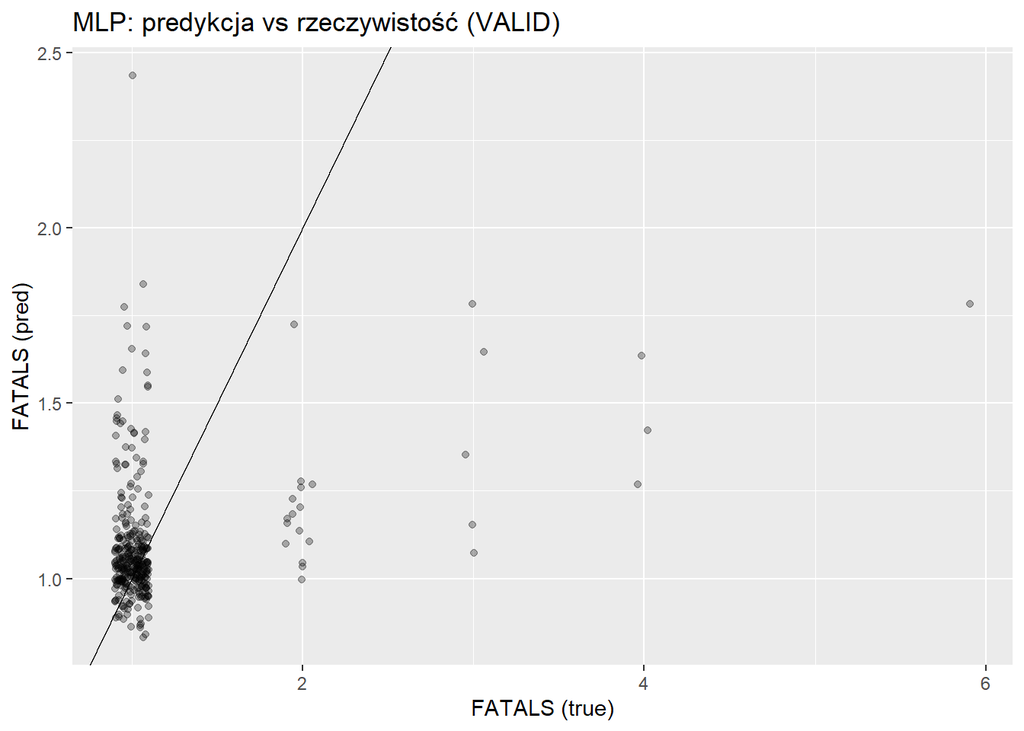

```r
best_mlp <- mlp3


mlp_valid_pred <- if (identical(best_mlp, mlp3)) {
  as.numeric(predict(best_mlp$model, as.matrix(X_valid_s)))
} else {
  as.numeric(predict(best_mlp$model, as.matrix(X_valid)))
}

plot_mlp_df <- data.frame(FATALS_true = y_valid, FATALS_pred = mlp_valid_pred)


ggplot(plot_mlp_df, aes(x = FATALS_true, y = FATALS_pred)) +
  geom_jitter(width = 0.1,
              height = 0.05,
              alpha = 0.3) +
  geom_abline(slope = 1, intercept = 0) +
  labs(title = "MLP: predykcja vs rzeczywistość (VALID)", x = "FATALS (true)", y = "FATALS (pred)")
```

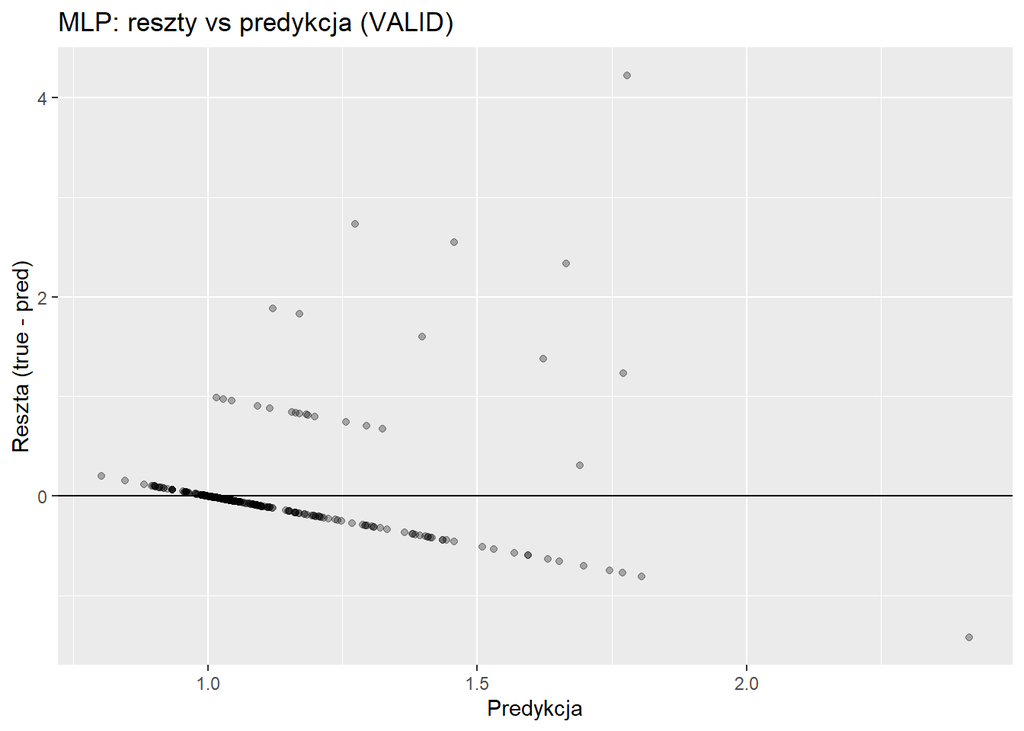

```r
plot_mlp_df$resid <- plot_mlp_df$FATALS_true - plot_mlp_df$FATALS_pred

ggplot(plot_mlp_df, aes(x = FATALS_pred, y = resid)) +
  geom_hline(yintercept = 0) +
  geom_point(alpha = 0.3) +
  labs(title = "MLP: reszty vs predykcja (VALID)", x = "Predykcja", y = "Reszta (true - pred)")
```

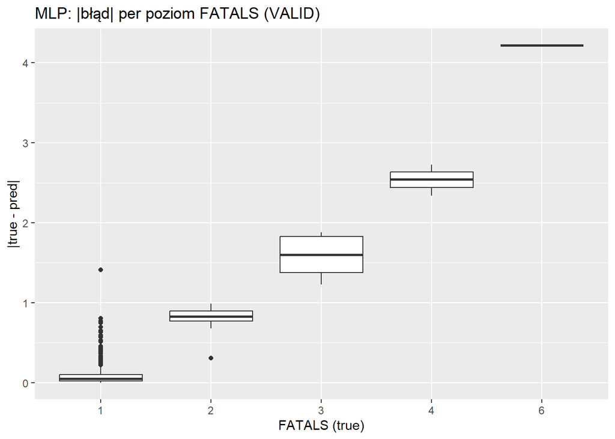

```r
plot_mlp_df$abs_err <- abs(plot_mlp_df$resid)

ggplot(plot_mlp_df, aes(x = factor(FATALS_true), y = abs_err)) +
  geom_boxplot() +
  labs(title = "MLP: |błąd| per poziom FATALS (VALID)", x = "FATALS (true)", y = "|true - pred|")
```

**Komentarz:** MLP: predykcja vs rzeczywistość (VALID) Punkty układają się blisko linii y=x dla FATALS=1, ale dla wyższych wartości widać, że model zwykle nie dobija do 2–6 (predykcje są za niskie). To typowy efekt niezbalansowania.

MLP: reszty vs predykcja (VALID) Jeśli dla większych FATALS reszty robią się dodatnie (true - pred > 0), to znaczy, że MLP systematycznie zaniża duże FATALS. Jeśli reszty są wokół zera głównie przy 1, to model „dobrze umie jedynki”.

MLP: |błąd| per poziom FATALS (VALID) Dla FATALS=1 błędy są małe, a dla FATALS=2,3,4… błędy rosną (bo model nie ma dość przykładów i regresja ciągnie do średniej).

### Predykcje MLP dla 4 obserwacji (zbiór predykcyjny)

```r
mlp1$pred_table
```

| FATALS_true | pred_raw | pred_round |
| --- | --- | --- |
| 1 | 1.0789753 | 1 |
| 1 | 1.0526563 | 1 |
| 1 | 0.9984345 | 1 |
| 1 | 1.0157561 | 1 |

```r
mlp2$pred_table
```

| FATALS_true | pred_raw | pred_round |
| --- | --- | --- |
| 1 | 1.0965064 | 1 |
| 1 | 1.1234053 | 1 |
| 1 | 0.9756703 | 1 |
| 1 | 1.0466351 | 1 |

```r
mlp3$pred_table
```

| FATALS_true | pred_raw | pred_round |
| --- | --- | --- |
| 1 | 1.1576926 | 1 |
| 1 | 1.0293208 | 1 |
| 1 | 0.9961674 | 1 |
| 1 | 1.0112861 | 1 |

**Komentarz :** * Dla **4 obserwacji predykcyjnych** wszystkie warianty MLP dały **predykcję po zaokrągleniu = 1** i to się zgadza z prawdą (**FATALS_true = 1**), więc na tym mini-zbiorze każdy wariant „trafił”. * Kolumna **pred_raw** pokazuje surowe wyjście sieci (wartości ciągłe) – kręci się ono **bardzo blisko 1** (ok. 0.98–1.16), czyli model ma silną tendencję do przewidywania „typowego” przypadku. * Ponieważ te 4 przypadki są wszystkie z klasy **1**, ten fragment **nie rozróżnia wariantów** (każdy wygląda dobrze). Sensowne porównanie powinny być głównie na **walidacji (RMSE/MAE)** i na błędach dla rzadkich wartości **FATALS ≥ 2**.

## 5.4 Model 2: Random Forest (regresja)

```r
set.seed(123)

rf_model <- randomForest(FATALS ~ .,
                         data = train,
                         ntree = 500,
                         importance = TRUE)
```

```
## Warning in randomForest.default(m, y, ...): The response has five or fewer
## unique values.  Are you sure you want to do regression?
```

**Uwaga o ostrzeżeniu (RF):** W konsoli pojawia się ostrzeżenie, że zmienna `FATALS` ma mało unikalnych wartości. Wynika to z faktu, że `FATALS` jest liczbą całkowitą (dyskretna), ale nadal jest to problem regresyjny, bo przewidujemy *liczbę* ofiar. Dlatego oceniam modele metrykami regresji (RMSE, MAE), a nie klasyfikacją.

### Ocena RF na walidacji

```r
rf_valid_pred <- predict(rf_model, newdata = valid)
rmse_rf <- sqrt(mean((valid$FATALS - rf_valid_pred)^2))
mae_rf  <- mean(abs(valid$FATALS - rf_valid_pred))

rmse_rf
```

```
## [1] 0.4643623
```

```r
mae_rf
```

```
## [1] 0.174898
```

### Diagnostyka RF: predykcja vs prawda, reszty, błąd per poziom

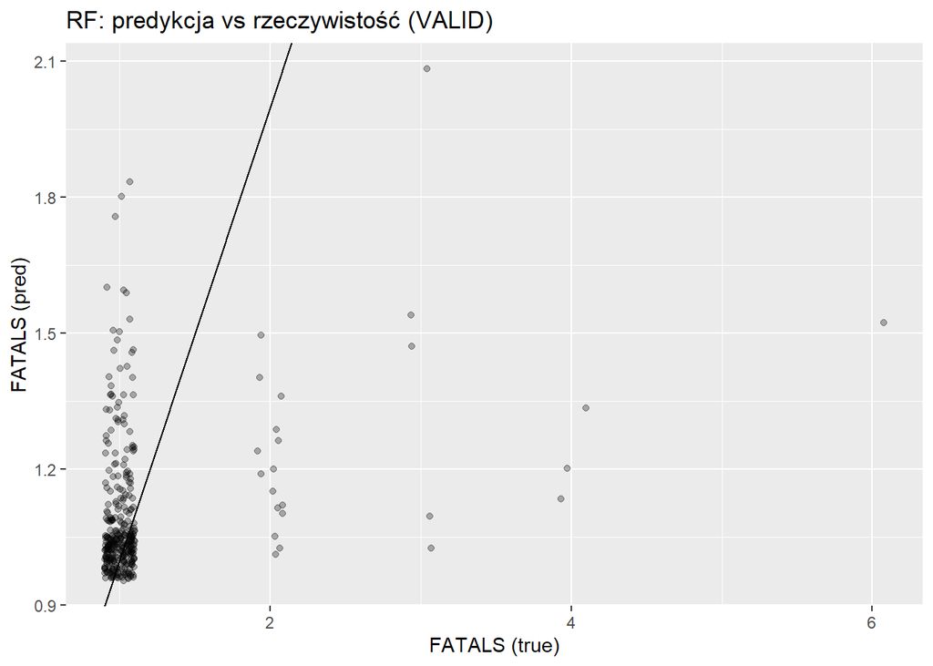

```r
plot_rf_df <- data.frame(FATALS_true = valid$FATALS,
                         FATALS_pred = as.numeric(rf_valid_pred))


ggplot(plot_rf_df, aes(x = FATALS_true, y = FATALS_pred)) +
  geom_jitter(width = 0.1,
              height = 0.05,
              alpha = 0.3) +
  geom_abline(slope = 1, intercept = 0) +
  labs(title = "RF: predykcja vs rzeczywistość (VALID)", x = "FATALS (true)", y = "FATALS (pred)")
```

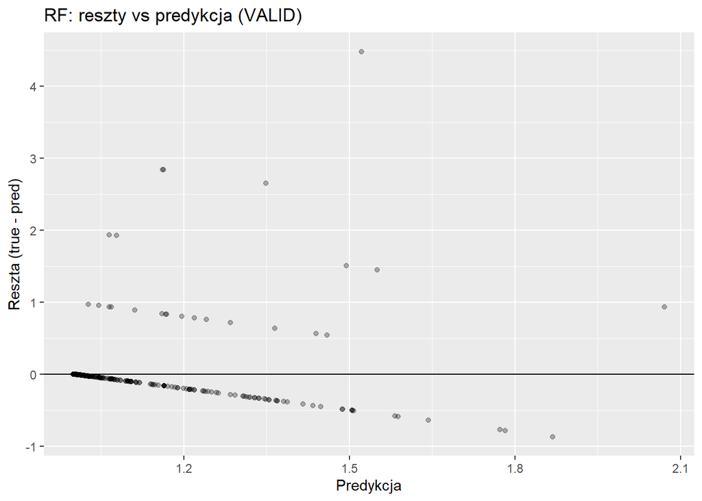

```r
plot_rf_df$resid <- plot_rf_df$FATALS_true - plot_rf_df$FATALS_pred

ggplot(plot_rf_df, aes(x = FATALS_pred, y = resid)) +
  geom_hline(yintercept = 0) +
  geom_point(alpha = 0.3) +
  labs(title = "RF: reszty vs predykcja (VALID)", x = "Predykcja", y = "Reszta (true - pred)")
```

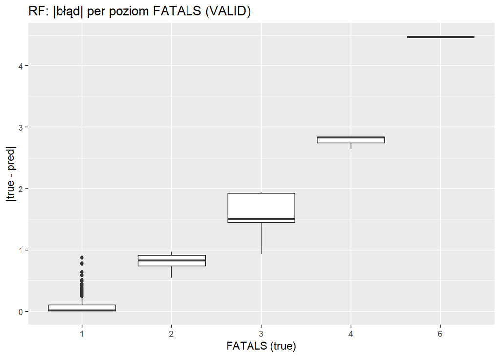

```r
plot_rf_df$abs_err <- abs(plot_rf_df$resid)

ggplot(plot_rf_df, aes(x = factor(FATALS_true), y = abs_err)) +
  geom_boxplot() +
  labs(title = "RF: |błąd| per poziom FATALS (VALID)", x = "FATALS (true)", y = "|true - pred|")
```

**Komentarz:** RF: predykcja vs rzeczywistość (VALID) Zwykle podobny obraz jak w MLP, ale RF często jest trochę stabilniejszy i daje minimalnie lepsze dopasowanie (MAE jest niższe niż w MLP). Nadal problemem są rzadkie wysokie FATALS.

RF: reszty vs predykcja (VALID) Jeśli reszty są mniejsze niż w MLP (mniej dużych odchyleń), to RF lepiej „łapie” zależności. Jeżeli wciąż duże FATALS są zaniżane — to znów kwestia niezbalansowania.

RF: |błąd| per poziom FATALS (VALID) Najniższe błędy będą przy FATALS=1, a przy 2+ widać skok — to pokazuje, że oba modele są oceniane głównie na „łatwej” masie danych.

### Predykcja RF dla 4 obserwacji

```r
rf_pred4 <- predict(rf_model, newdata = pred)
data.frame(FATALS_true = pred$FATALS,
           FATALS_pred = as.numeric(rf_pred4))
```

| FATALS_true | FATALS_pred |
| --- | --- |
| 1 | 1.086795 |
| 1 | 1.034160 |
| 1 | 1.001193 |
| 1 | 1.004936 |

### Ważność zmiennych w RF

```r
importance(rf_model)
```

```
##             %IncMSE IncNodePurity
## VE_TOTAL  8.0613492     11.075492
## PERSONS  21.5053099     39.128151
## PEDS      9.4208059      5.783965
## NO_LANES  1.0964980     11.780203
## SP_LIMIT -0.6951102     18.591689
## DRUNK_DR  7.7764605     14.347960
```

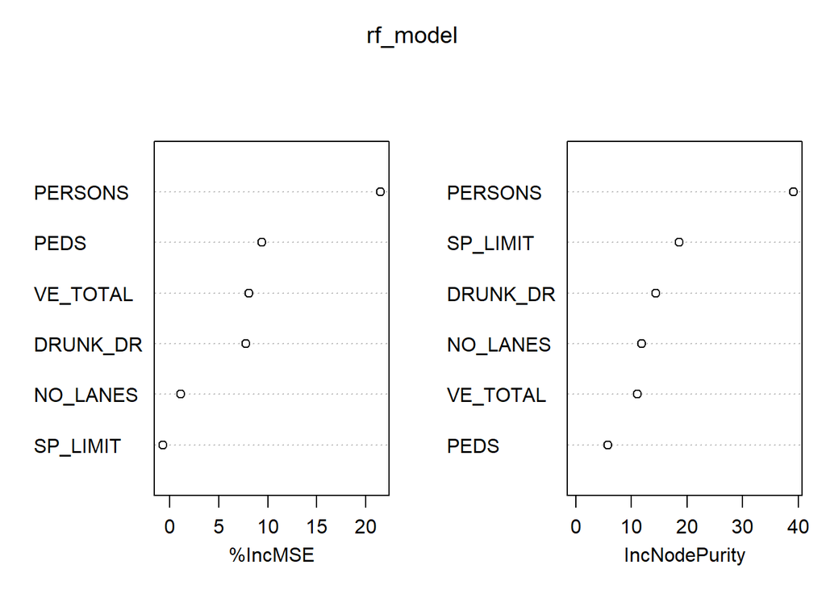

```r
varImpPlot(rf_model)
```

**Komentarz:** Ważność mówi, które cechy najbardziej pomagają przewidywać FATALS. Najwyżej jest PERSONS, potem PEDS/DRUNK_DR/VE_TOTAL, a np. SP_LIMIT bywa mało istotny (czasem nawet ujemny %IncMSE → w praktyce niewiele wnosi albo szumi). To fajnie spina się z wcześniejszymi wykresami zależności.

# 6. Evaluation + Comparison

## 6.1 Błąd per poziom FATALS (VALID) — MLP vs RF

```r
mlp_err_df <- data.frame(FATALS_true = y_valid,
                         FATALS_pred = as.numeric(mlp_valid_pred)) %>%
  mutate(abs_err = abs(FATALS_true - FATALS_pred),
         Model = "MLP")

rf_err_df <- data.frame(FATALS_true = valid$FATALS,
                        FATALS_pred = as.numeric(rf_valid_pred)) %>%
  mutate(abs_err = abs(FATALS_true - FATALS_pred),
         Model = "RF")

err_summary <- bind_rows(mlp_err_df, rf_err_df) %>%
  group_by(Model, FATALS_true) %>%
  summarise(
    n = n(),
    mean_abs_err = mean(abs_err),
    median_abs_err = median(abs_err),
    .groups = "drop"
  ) %>%
  arrange(Model, FATALS_true)

err_summary
```

| Model | FATALS_true | n | mean_abs_err | median_abs_err |
| --- | --- | --- | --- | --- |
| MLP | 1 | 323 | 0.10490423 | 0.04665980 |
| MLP | 2 | 15 | 0.80555768 | 0.83005665 |
| MLP | 3 | 5 | 1.58349226 | 1.60142231 |
| MLP | 4 | 3 | 2.53473131 | 2.54340588 |
| MLP | 6 | 1 | 4.22124695 | 4.22124695 |
| RF | 1 | 323 | 0.08719993 | 0.01694686 |
| RF | 2 | 15 | 0.79852228 | 0.83052123 |
| RF | 3 | 5 | 1.54827464 | 1.50569652 |
| RF | 4 | 3 | 2.77553893 | 2.83695852 |
| RF | 6 | 1 | 4.47820409 | 4.47820409 |

**Co tu widać:** - Dla `FATALS = 1` błąd jest mały (najwięcej danych). - Dla `FATALS >= 3` błędy rosną mocno (bo bardzo mało obserwacji).

## 6.2 Tabela porównania metryk (VALID) + predykcje 4 obserwacji

```r
results_compare <- bind_rows(
  best_mlp$metrics %>% mutate(Model = "MLP"),
  data.frame(
    Variant = "RandomForest",
    RMSE_valid = rmse_rf,
    MAE_valid = mae_rf,
    Model = "RF"
  )
) %>% select(Model, Variant, RMSE_valid, MAE_valid)

results_compare
```

| Model | Variant | RMSE_valid | MAE_valid |
| --- | --- | --- | --- |
| MLP | MLP_small_feat (6 cech, size=3, decay=0.01) | 0.4551954 | 0.189367 |
| RF | RandomForest | 0.4643623 | 0.174898 |

```r
pred_compare <- data.frame(
  FATALS_true = pred$FATALS,
  MLP_pred_raw = best_mlp$pred_table$pred_raw,
  MLP_pred_round = best_mlp$pred_table$pred_round,
  RF_pred_raw = as.numeric(rf_pred4),
  RF_pred_round = pmax(0, round(as.numeric(rf_pred4)))
)

pred_compare
```

| FATALS_true | MLP_pred_raw | MLP_pred_round | RF_pred_raw | RF_pred_round |
| --- | --- | --- | --- | --- |
| 1 | 1.1576926 | 1 | 1.086795 | 1 |
| 1 | 1.0293208 | 1 | 1.034160 | 1 |
| 1 | 0.9961674 | 1 | 1.001193 | 1 |
| 1 | 1.0112861 | 1 | 1.004936 | 1 |

# 7. Wnioski końcowe

- Dane są mocno **niezbalansowane**: prawie wszystkie obserwacje mają **FATALS = 1**, więc oba modele naturalnie „ciągną” predykcje w okolice 1 i gorzej radzą sobie z rzadkimi przypadkami 2–6.
- Najbardziej sensowną informację o liczbie ofiar niosą cechy związane ze „skalą zdarzenia”, szczególnie **PERSONS** (i w mniejszym stopniu **PEDS, DRUNK_DR, VE_TOTAL**), co potwierdzają wykresy zależności i ważność zmiennych w RF.
- W porównaniu modeli na walidacji: **MLP (wybrany wariant)** ma nieco lepszy **RMSE**, a **Random Forest** ma lepszy **MAE** – czyli RF średnio myli się mniej, a MLP czasem lepiej „trafia” w sensie kwadratowego błędu.
- Oba modele poprawnie przewidują przypadki typowe (FATALS≈1), ale dla wyższych wartości **najczęściej zaniżają** liczbę ofiar, co widać po resztach i rosnącym błędzie dla FATALS≥2.
- Predykcje dla 4 obserwacji testowych są spójne między modelami i bliskie wartościom rzeczywistym (w tych przypadkach również FATALS=1).